# Online-Recruiting (OR)

Pia Nolte, Anika Berghahn, Christina Koerfers

24.01.2020

# Fragestellung

**Wie wird Online-Recruiting (OR) von unterschiedlichen Altersgruppen wahrgenommen und welche Faktoren beeinflussen diese Wahrnehmung?**

# 1 Hintergrund der Forschungsfrage

Referenzpaper: *Catarina Brandaoa, Rita Silvaa, Joana Vieira dos Santos: Online recruiting in Portugal. Theories and candidate profiles. In: Journal of Business Research 94 (2019), p. 273-279.*

- Online-Recruiting (OR) = Digitaler Bewerbungsprozess, beispielsweise über Online-Portale oder die Website des jeweiligen Arbeitgebers

## 1.1 Zu replizierendes Ergebnis:

Fokus auf Wahrnehmung:

- überwiegend positiv bei einer jungen, gut gebildeten Personengruppe
- kritisch bei älteren Personengruppen
- wird durch einzelne Faktoren beeinflusst

## 1.2 Kernaussagen des Referenzpapers:

- OR wird von Arbeitnehmern gut angenommen (48% der Befragten bewerten OR positiv)
- Aber: Der Prozess ist unpersönlich
- Faktoren, die die Wahrnehmung beeinflussen: Praktikablität, Effizienz, Sicherheit, Interaktion, Zielgruppenerschließung etc.
- Nutzerprofil: weiblich, Millennial, Bachelorabschluss

# 2 Unterschiedshypothesen

1. Hypothese: Online-Recruiting wird positiv wahrgenommen.
- Verfahren: einfacher t-Test
- t.test(datensatz$ORAW, mu=3,5)
- H0: Die Wahrnehmung von Online-Recruiting liegt bei mu=3,5 (OR wird neutral gesehen)
- H1: Online-Recruiting wird nicht neutral wahrgenommen.
2. Hypothese: Studierende nutzen Online-Recruiting eher als Rentner.
- Verfahren: unverbundener t-Test
- t.test(datensatz$ORE ~ datensatz-activity)
- H0: (Nicht-)Nutzung von Online-Recruiting unterscheidet sich nicht zwischen Studierenden und Rentnern.
- H1: Es gibt einen Unterschied in der Nutzung von Online-Recruiting zwischen Studierenden und Rentnern.
3. Hypothese: Wer schon einmal OR genutzt hat, legt Wert auf die Interaktion zwischen Bewerber und Unternehmen.
- Verfahren: one-way ANOVA
- anova(datensatz, dep=“ORRPI“, factors= c(“ore1“))
- H0: Die persönlichen Erfahrungen mit OR beeinflussen die Bewertung der Interaktion im Bewerbungsprozess nicht.
- H1: Die persönlichen Erfahrungen mit OR beeinflussen die Bewertung der Interaktion im Bewerbungsprozess.
4. Hypothese: Frauen mit einem höheren Bildungsabschluss nehmen OR als sicherer, günstiger und schneller im Vergleicht zu traditionellen Bewerbungsverfahren wahr.
- Verfahren: zweifaktorielle MANOVA
- mancova(datensatz, deps = c(“ORRPS“, “ORRPK“, “ORRPZ“), factors = c(“gender“, “education“))
- H0: Die Wahrnehmung von Sicherheit, Kostenfaktoren und zeitliche Faktoren bezüglich OR sind unabhängig von Geschlecht und Schulabschluss.
- H1: Die Wahrnehmung von Sicherheit, Kostenfaktoren und zeitliche Faktoren bezüglich OR sind abhängig von Geschlecht und Schulabschluss.
5. Hypothese: Junge Frauen nehmen OR als praktisch und effizient und einfach (für jeden) zugänglich wahr.
- Verfahren: einfaktorielle MANCOVA
- mancova(datensatz, deps=c(“ORRPPE“, “ORRPZG“), factors = c(gender), covs=c(“age“))
- H0: Geschlecht und Alter wirken sich nicht auf die Wahrnehmung von Praktikabilität/Effizienz und die Zielgruppenerschließung bezüglich OR aus.
- H1: Geschlecht und Alter wirken sich auf die Wahrnehmung von Praktikabilität/Effizienz und die Zielgruppenerschließung bezüglich OR aus.

# 3 Zusammenhangshypothesen

1. Hypothese: Das Alter hängt mit der Wahrnehmung von OR zusammen.
- Korrelation
2. Hypothese: Je älter man ist, desto negativer ist die Wahrnehmung von OR.
- Lineare Regression
3. Hypothese: Negative Wahrnehmung von OR hängt zusammen mit schlechterer Bewertung von zeitlichen Faktoren.
- Korrelation
4. Hypothese: Je höher der KUT, desto praktischer/effizienter wird OR wahrgenommen.
- Lineare Regression
5. Hypothese: Es gibt einen Zusammenhang zwischen KUT und allgemeiner Wahrnehmung.
- Korrelation

# 4 Faktorenraum

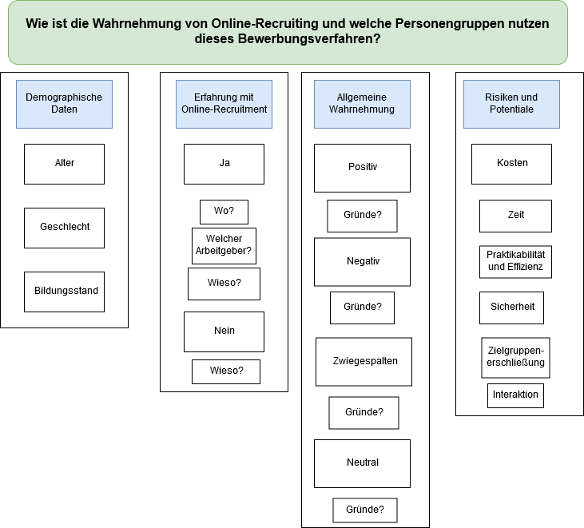

Faktorenraum